# Lab 4

Charlie Curtin

2024-04-24

Lab 4 Assignment: Due May 7 at 11:59pm

1. Select another classification algorithm.
2. Conduct an initial out-of-the-box model fit on the training data and prediction on the test data. Assess the performance of this initial model.
3. Select the relevant hyperparameters for your algorithm and tune your model.
4. Conduct a model fit using your newly tuned model specification. How does it compare to your out-of-the-box model?
5. 1. Use variable importance to determine the terms most highly associated with non-fatal reports? What about terms associated with fatal reports? OR
   2. If you aren’t able to get at variable importance with your selected algorithm, instead tell me how you might in theory be able to do it. Or how you might determine the important distinguishing words in some other way.
6. Predict fatality of the reports in the test set. Compare this prediction performance to that of the Naive Bayes and Lasso models. Why do you think your model performed as it did, relative to the other two?

## read in and prepare data for modeling

```r
# load climbing accidents data
urlfile ="https://raw.githubusercontent.com/MaRo406/EDS-231-text-sentiment/main/data/climbing_reports_model_dat.csv"

incidents_df<-readr::read_csv(url(urlfile))

## split into training and testing data
set.seed(1234)

# turn the fatal binary into classes
incidents2class <- incidents_df %>%
  mutate(fatal = factor(if_else(
                        is.na(Deadly),
                        "non-fatal", "fatal")))


incidents_split <- initial_split(incidents2class, strata = fatal)

incidents_train <- training(incidents_split)
incidents_test <- testing(incidents_split)

# create folds for k-folds cross-validation
incidents_folds <- vfold_cv(incidents_train)

# specify a recipe to predict fatalities based on the text
incidents_rec <- recipe(fatal ~ Text, data = incidents_train)

# add preprocessing steps
recipe <- incidents_rec %>%
  # create word tokens based on the contents of text
  step_tokenize(Text) %>%
  # filter to the most common words
  step_tokenfilter(Text, max_tokens = 1000) %>%
  # calculate the tf-idf
  step_tfidf(Text)
```

## random forest model- no tuning

Running a random forest model to predict fatalities without tuning any hyperparameters

```r
# specify a random forest as our chosen model
rf_spec <- rand_forest() %>%
  set_engine("ranger") %>%
  set_mode("classification")

# bundle our model spec and recipe into a workflow
rf_wf <- workflow() %>%
  add_recipe(recipe) %>%
  add_model(rf_spec)

# estimate performance with resampling
rf_rs <- fit_resamples(
  rf_wf,
  incidents_folds,
  control = control_resamples(save_pred = TRUE)
)

# collect performance metrics and predictions
rf_rs_metrics <- collect_metrics(rf_rs)
rf_rs_predictions <- collect_predictions(rf_rs)

# print accuracy
print(paste("accuracy of untuned random forest model:", round(rf_rs_metrics[1,3], 2)))
```

```
## [1] "accuracy of untuned random forest model: 0.86"
```

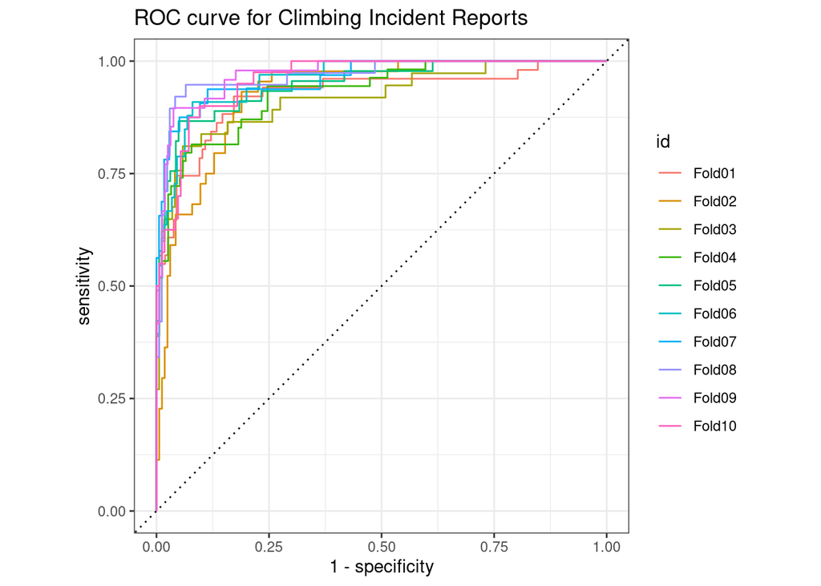

```r
# graph the roc auc curve for the random forest classification model
rf_rs_predictions %>%
  group_by(id) %>%
  roc_curve(truth = fatal, .pred_fatal) %>%
  autoplot() +
  labs(title = "ROC curve for Climbing Incident Reports")
```

## random forest model- tuning

Tuning the trees() parameters for our random forest model

```r
# specify a random forest as our chosen model
rf_tune <- rand_forest(trees = tune()) %>%
  set_engine("ranger",
             importance = "impurity") %>%
  set_mode("classification")

# bundle our model spec and recipe into a workflow
rf_tune_wf <- workflow() %>%
  add_recipe(recipe) %>%
  add_model(rf_tune)

# set up a tune grid of possible values
rf_grid <- grid_regular(
  trees(c(500, 1000)),
  levels = 5
)

# estimate performance with resampling and tuning
run_time <- system.time({
  rf_tune_rs <- tune_grid(
    rf_tune_wf,
    resamples = incidents_folds,
    grid = rf_grid,
    control = control_grid(save_pred = TRUE)
  )
})

# select the best model based on accuracy
best_rf <- select_best(rf_tune_rs, metric = "accuracy")
rf_tune_rs_metrics <- show_best(rf_tune_rs, n = 3, metric = "accuracy")

# finalize workflow with the best random forest model
final_rf_wf <- finalize_workflow(rf_tune_wf, best_rf)

# fit the model to the training data
final_rf_fit <- fit(final_rf_wf, data = incidents_train)

# get predictions used the fitted model
rf_tune_predictions <- predict(final_rf_fit, new_data = incidents_test) %>%
  bind_cols(incidents_test)

# print accuracy of our model
print(paste("accuracy of tuned random forest model:", round(rf_tune_rs_metrics[1,4], 2)))
```

```
## [1] "accuracy of tuned random forest model: 0.87"
```

I tuned the random forest model to select the best number of trees to grow between 500 and 1000, and 1000 looks to be the best based on accuracy. However, this accuracy was only marginally better than the untuned model, with a value .87 as opposed to .86 in the untuned model.

## variable importance

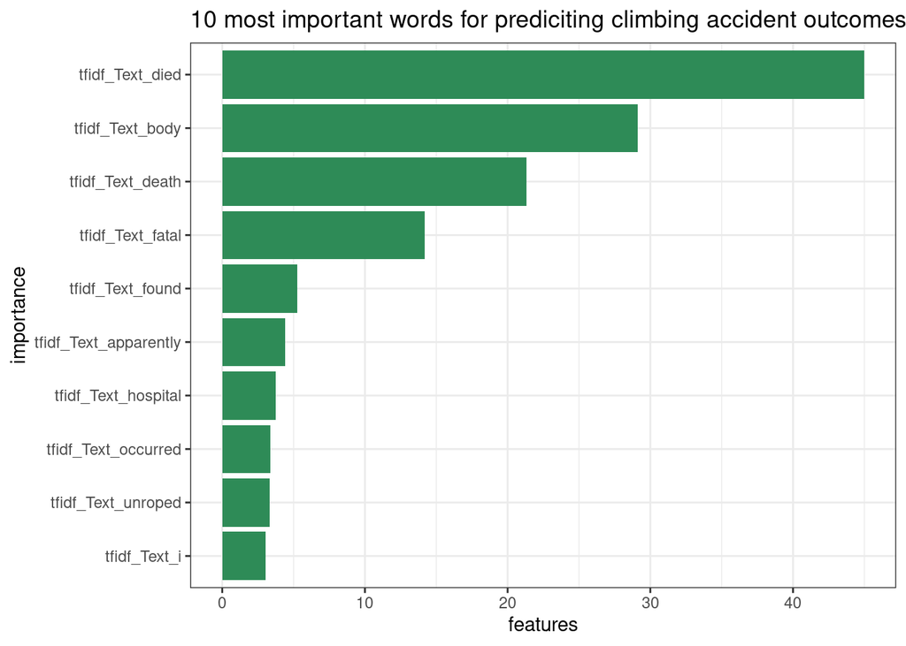

```r
# extract fit from the random forest
rf_model <- extract_fit_parsnip(final_rf_fit)

# create variable importance plot for predicting fatal
vip(rf_model, num_features = 10) +
  geom_col(fill = "seagreen") +
  labs(title = "10 most important words for prediciting climbing accident outcomes",
       x = "importance",
       y = "features") +
  theme_bw()
```

The variable importance plot shows the top 10 words most influential in predicting climbing accident outcomes accurately, whether they are fatal or non-fatal. Intuitively, some of the words seem to indicate that they would be important for predicting fatalities, like “died”, “death”, and “fatal”. Others would indicate that they are important for predicting non-fatalities, like “found”.

## Compare prediction performance of the tuned model to the naive bayes and lasso models

```r
# use our fitted model to create predictions on the testing data and collect performance metrics
rf_tune_metrics <- last_fit(final_rf_fit, incidents_split) %>%
  collect_metrics()

# print accuracy and roc auc of predictions on the testing data
print(paste("accuracy of tuned random forest model:", round(rf_tune_metrics[1,3], 2)))
```

```
## [1] "accuracy of tuned random forest model: 0.87"
```

```r
print(paste("ROC AUC of tuned random forest model:", round(rf_tune_metrics[2,3], 2)))
```

```
## [1] "ROC AUC of tuned random forest model: 0.96"
```

The lasso model we tuned in the lab demo gave an accuracy of around .92 and an ROC AUC of around .95. The models perform similarly, but the lasso model performs slightly better in terms of accuracy. I only tuned the trees parameter with the random forest model, which only slightly improved the performance as compared to the untuned model. I could’ve tuned other hyperparameters too like min_n or mtry with the random forest model to see if they improved performance even more, which might explain the difference in performance.